# Tracer des graphiques avec R

Nous allons maintenant voir comment explorer de la donnée au travers de plusieurs graphiques, la librairie exploitée sera ggplot2, comprise dans tidyverse. Un cheat sheet se trouve [ici](https://www.rstudio.com/wp-content/uploads/2015/03/ggplot2-cheatsheet.pdf) pour ggplot2.  
Bien entendu il existe également d’autres librairies graphiques telles que plotly (existante également sur Python), permettant de réaliser des graphiques intéractifs, exportables au format HTML, PDF, etc. Nous utiliserons une fois encore un fichier issu d’une compétition kaggle, référençant une liste d’airbnb de la ville Melbourne en Australie.

# Objectifs

- Savoir tracer des graphiques avec une, deux ou plusieurs variables
- Se familiariser avec la bibliothèque ggplot2
- Comprendre comment visualiser la répartition d’une variable
- Mettre en avant les liens existant ou non entre plusieurs variables

# Récupération du fichier

Le fichier est [ici](https://www.kaggle.com/tylerx/melbourne-airbnb-open-data#listings_summary_dec18.csv)  
Allez dans la partie “Data” > “Data Sources” > Sélectionnez “listings_summary_dec18.csv” > en-dessous cliquez sur l’icone download.

# Lecture des fichiers

```r
library(tidyverse)

df = read_csv('C:/Users/DIONGA/Downloads/dataset/melbourne airbnb/listings_summary_dec18.csv')
df
```

| id | name | host_id | host_name | neighbourhood_group | neighbourhood | latitude | longitude | room_type | price | minimum_nights | number_of_reviews | last_review | reviews_per_month | calculated_host_listings_count | availability_365 |
| --- | --- | --- | --- | --- | --- | --- | --- | --- | --- | --- | --- | --- | --- | --- | --- |
| 9835 | Beautiful Room & House | 33057 | Manju | NA | Manningham | -37.77268 | 145.0921 | Private room | 60 | 1 | 4 | 2015-09-12 | 0.04 | 1 | 365 |
| 10803 | Room in Cool Deco Apartment in Brunswick | 38901 | Lindsay | NA | Moreland | -37.76651 | 144.9807 | Private room | 35 | 3 | 108 | 2018-11-26 | 1.50 | 1 | 213 |
| 12936 | St Kilda 1BR APT+BEACHSIDE+VIEWS+PARKING+WIFI+AC | 50121 | Frank & Vince | NA | Port Phillip | -37.85976 | 144.9774 | Entire home/apt | 159 | 3 | 15 | 2018-11-07 | 0.15 | 17 | 326 |
| 15246 | Large private room-close to city | 59786 | Eleni | NA | Darebin | -37.75897 | 144.9892 | Private room | 50 | 2 | 29 | 2017-05-15 | 0.30 | 3 | 0 |
| 16760 | Melbourne BnB near City & Sports | 65090 | Colin | NA | Port Phillip | -37.86453 | 144.9922 | Private room | 69 | 1 | 63 | 2018-11-22 | 0.74 | 1 | 328 |
| 38271 | Melbourne - Old Trafford Apartment | 164193 | Daryl | NA | Casey | -38.05725 | 145.3394 | Entire home/apt | 98 | 1 | 112 | 2018-12-01 | 1.14 | 1 | 328 |
| 41836 | CLOSE TO CITY & MELBOURNE AIRPORT | 182833 | Diana | NA | Darebin | -37.69729 | 145.0008 | Private room | 50 | 7 | 159 | 2018-08-22 | 1.62 | 3 | 0 |
| 43414 | Home In The City | 189682 | Belinda | NA | Melbourne | -37.81027 | 144.9859 | Private room | 100 | 1 | 3 | 2018-11-05 | 0.29 | 1 | 11 |
| 43429 | Tranquil Javanese-Style Apartment in Oakleigh East | 189684 | Allan | NA | Monash | -37.89960 | 145.1145 | Entire home/apt | 98 | 2 | 168 | 2018-12-03 | 1.72 | 1 | 310 |
| 44082 | Queen Room in Beautiful House | 193031 | Vicki | NA | Frankston | -38.14932 | 145.1416 | Private room | 60 | 3 | 28 | 2018-10-13 | 0.29 | 5 | 310 |

[output cut: 990 more lines]

# Analyses Univariées (une seule variable)

## Histogramme - variable continue (un grand nombre de valeurs distinctes)

Ici on souhaite afficher un histogramme concernant le prix des airbnb, pour connaitre la distribution de cette variable.  
On lui passe donc la variable price, on lui précise de découper le graphique en 100 barres, de se limiter à l’affichage des prix compris entre 0 et 1000, ensuite la fonction seq(0, 1000, 50), détermine l’échelle de l’axe x, on affiche l’axe x de 0 à 1000 par pas de 50.

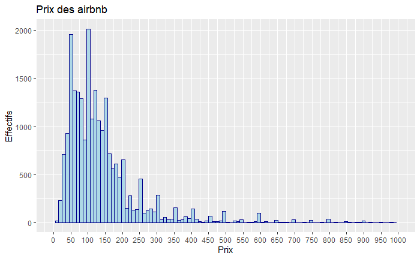

```r
ggplot(df) +
  aes(price) +
  geom_histogram(bins = 100, fill="lightblue", color="darkblue") +
  scale_x_continuous(breaks = seq(0, 1000, 50), limit=c(0,1000)) +
  ggtitle("Prix des airbnb") +
  xlab("Prix") +
  ylab("Effectifs")
```

On voit ici que les prix sont principalement situés entre 25€ et 200€, avec une forte densité entre 50 et 150€.

## Courbe gaussian

On affiche ici la densité sous forme de courbe, afin de voir si la variable prix pourrait suivre une loi normale.  
On passe le paramètre adjust=2, afin de lisser la courbe.

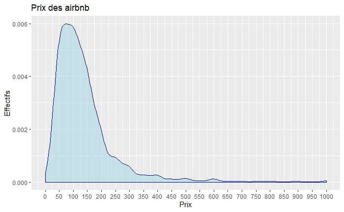

```r
ggplot(df) +
  aes(price) +
  geom_density(kernel = "gaussian", adjust=2, fill="lightblue", color="darkblue", alpha=0.6) +
  scale_x_continuous(breaks = seq(0, 1000, 50), limit=c(0,1000)) +
  ggtitle("Prix des airbnb") +
  xlab("Prix") +
  ylab("Effectifs")
```

## Courbe gaussian centrée réduite

Avec la focntion scale(), on centre la variable, c’est à dire que la moyenne des prix est soustraite à chaque valeur, puis réduite, c’est à dire qu’on divise chaque valeur par l’écart type.

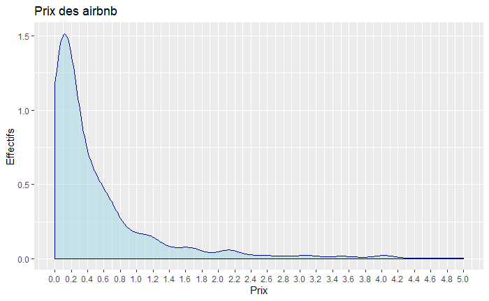

```r
ggplot(df) +
  aes(scale(price)) +
  geom_density(kernel = "gaussian", adjust=2, fill="lightblue", color="darkblue", alpha=0.6) +
  scale_x_continuous(breaks = seq(0, 5, 0.2), limit=c(0,5)) +
  ggtitle("Prix des airbnb") +
  xlab("Prix") +
  ylab("Effectifs")
```

On observe donc que les prix sont fortement regroupés, avec une longue queue de valeurs extrêmes (prix élevés). On aurait aussi pu utiliser l’échelle logarithmique `log2(price)`, ou la racine carrée de price `sqrt(price)`.

## Box plot ou boite à moustaches

La fonction ici permet d’afficher rapidement pour une variable le 1er et 3e quartile, médiane, moyenne, valeurs min et max, permettant d’apprécier d’une autre façon la répartition des valeurs.

```r
summary(df$price)
```

```
   Min. 1st Qu.  Median    Mean 3rd Qu.    Max.
      0      71     111     148     165   12624
```

Ici on l’affiche de manière graphique les résultats précédents, dont le principe est le suivant :

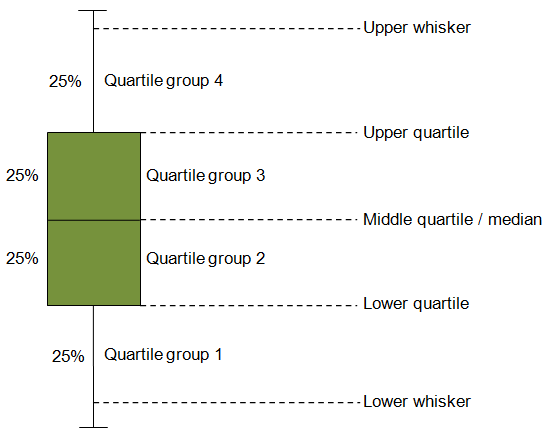

Il y a 25% des données entre chaque partie, les points représentes des valeurs extrêmes.

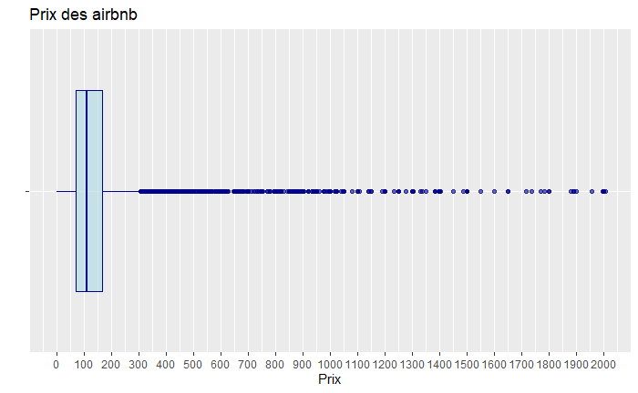

```r
ggplot(df) +
  aes(x = "", y = price) +
  geom_boxplot(na.rm = TRUE, fill="lightblue", color="darkblue", alpha=0.6) +
  coord_flip(ylim=c(0, 2000)) +
  scale_y_continuous(breaks = seq(0, 2000, 100)) +
  ggtitle("Prix des airbnb") +
  xlab("") +
  ylab("Prix")
```

## Diagramme de fréquence - variable discrète (quelques modalités)

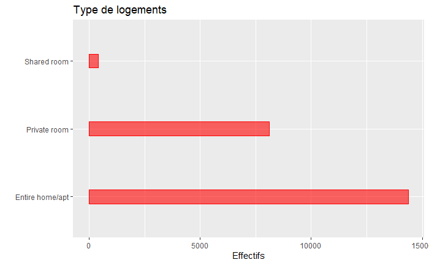

```r
ggplot(df) +
  aes(x = room_type) +
  geom_bar(color="red", fill="red", alpha=0.6, width=0.2) +
  coord_flip() +
  ggtitle("Type de logements") +
  xlab("") +
  ylab("Effectifs")
```

On s’aperçoit très rapidement que les chambres partagés ne représentent pas beaucoup de logements.

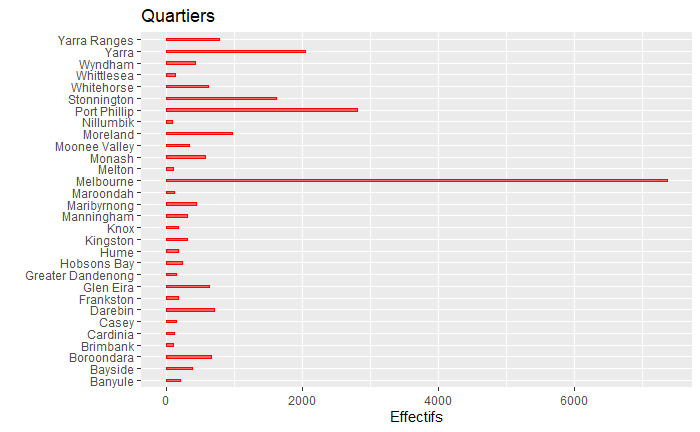

```r
ggplot(df) +
  aes(x = neighbourhood) +
  geom_bar(color="red", fill="red", alpha=0.6, width=0.2) +
  coord_flip() +
  ggtitle("Quartiers") +
  xlab("") +
  ylab("Effectifs")
```

On voit ici que le cartier de Melbourne représente plus de 7000 logements sur 22800, soit près d’un tiers.

# Analyses Bivariées (deux variables)

## Box plot ou diagramme à moustaches

Il pourrait être intéressant désormais d’afficher la répartition des prix, mais cette fois en fonction des quartier

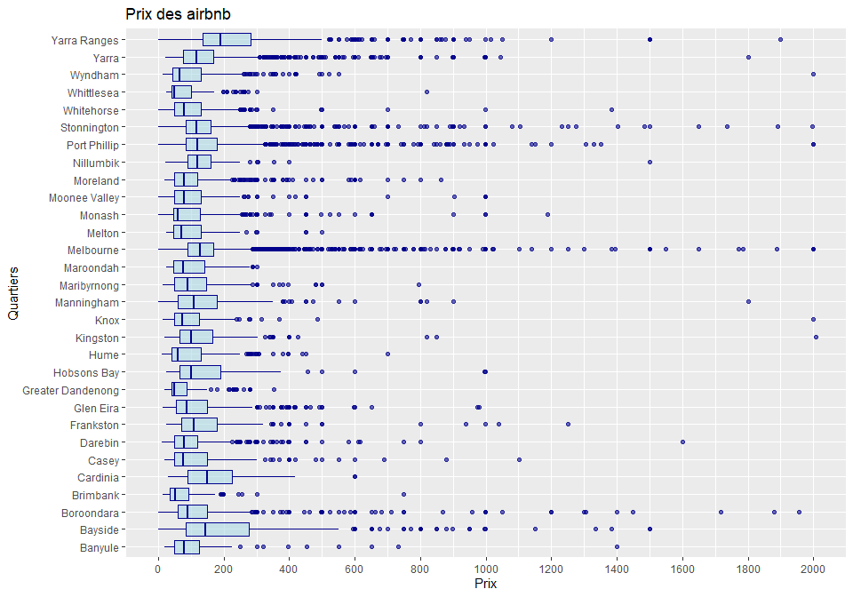

```r
ggplot(df) +
  aes(x = neighbourhood, y = price) +
  geom_boxplot(na.rm = TRUE, fill="lightblue", color="darkblue", alpha=0.6) +
  coord_flip(ylim=c(0, 2000)) +
  scale_y_continuous(breaks = seq(0, 2000, 200)) +
  ggtitle("Prix des airbnb") +
  xlab("Quartiers") +
  ylab("Prix")
```

On voit que certains quartiers comme Bayside ou Yarra Ranges possèdent une plus grande diversité de prix que Greater Dandenong par exemple. Egalement ces 2 quartiers ont leur dernier quartile avec des prix plus élevés.

## Nuage de points

A partir de là, d’autres idées commencent à émerger, on voudrait savoir qu’est ce qui tire les prix vers le haut, est-ce le type de logement (maison entière, chambre…), l’emplacement, …

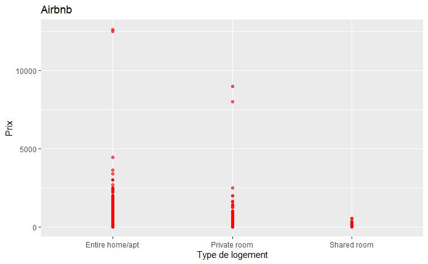

```r
ggplot(df) +
  aes(x = room_type, y = price) +
  geom_point(color="red", alpha=0.6) +
  ggtitle("Airbnb") +
  xlab("Type de logement") +
  ylab("Prix")
```

On voit ici que les prix montent plus haut sur un logement entier, ce qui parait relativement normal.

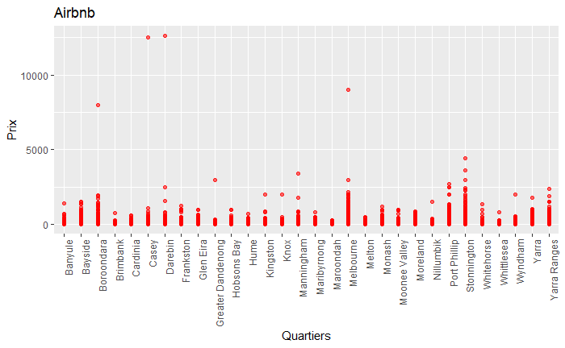

```r
ggplot(df) +
  aes(x = neighbourhood, y = price) +
  geom_point(color="red", alpha=0.6) +
  theme(axis.text.x = element_text(angle = 90, hjust = 1)) +
  ggtitle("Airbnb") +
  xlab("Quartiers") +
  ylab("Prix")
```

Là encore on voit que certains quartiers possèdent des valeurs très extrêmes de prix.

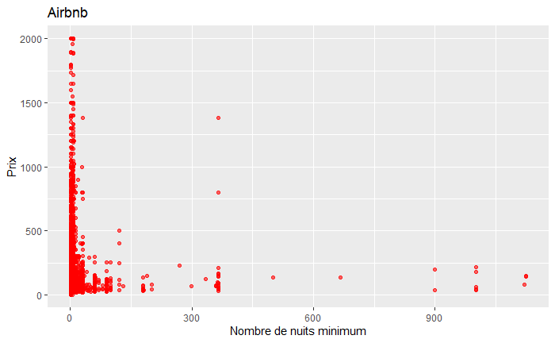

```r
ggplot(df) +
  aes(x = minimum_nights, y = price) +
  geom_point(color="red", alpha=0.6) +
  scale_y_continuous(limits = c(0, 2000)) +
  ggtitle("Airbnb") +
  xlab("Nombre de nuits minimum") +
  ylab("Prix")
```

On peut conclure ici qu’un certain nombre d’hébergeurs demandent un nombre de nuits minimum très élevé, il peut s’agir ici d’erreurs de saisies.  
La plupart demandent un nombre de nuits proche de 0, une autre colonne se lève après 300 jours, certainement des hébergeurs louant à l’année.

# Analyses multivariées

## Matrice de corrélation

On pourrait également se demander si revoir régulièrement son annonce et mettre régulièrement à jour ses textes permet de mieux louer.  
Autrement dit le nombre de revues et les disponibilités sont elles corrélées.  
Egalement le fait de mettre moins de nuits minimum, augmente t-il le nombre de réservations.

```r
var_comp <- df %>% select(availability_365, number_of_reviews, price, minimum_nights, number_of_reviews, calculated_host_listings_count, availability_365)

matrix_corr <-cor(var_comp)
head(round(matrix_corr,2))
```

```
                               availability_365 number_of_reviews price minimum_nights
availability_365                           1.00              0.14  0.11           0.00
number_of_reviews                          0.14              1.00 -0.03          -0.04
price                                      0.11             -0.03  1.00           0.02
minimum_nights                             0.00             -0.04  0.02           1.00
calculated_host_listings_count             0.14              0.06  0.08           0.00
                               calculated_host_listings_count
availability_365                                         0.14
number_of_reviews                                        0.06
price                                                    0.08
minimum_nights                                           0.00
calculated_host_listings_count                           1.00
```

Afin de mettre en forme cette matrice de corrélation, nous aurons besoin du pckage `corrplot` :

```r
install.packages("corrplot" ,repos='http://cran.r-project.org')
```

```
Error in install.packages : Updating loaded packages
```

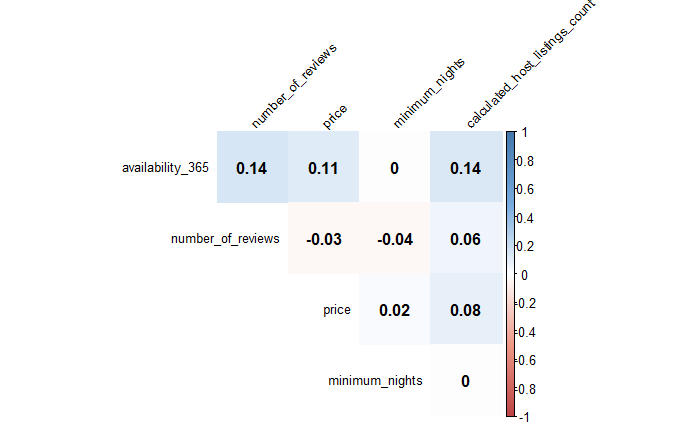

```r
library(corrplot)

col <- colorRampPalette(c("#BB4444", "#EE9988", "#FFFFFF", "#77AADD", "#4477AA"))
corrplot(matrix_corr, method="color", col=col(200), type="upper", tl.cex = 0.8,
         addCoef.col = "black", # Ajout du coefficient de corrélation
         tl.col="black", tl.srt=45, #Rotation des etiquettes de textes
         diag=FALSE # Cacher les coefficients de corrélation sur la diagonale
)
```

Un coefficent de corrélation évolue entre [-1;1], -1 signifiant une forte corrélation négative, 1 une forte corrélation positive. Ici le coefficent le plus élevé est 0.14, soit une faible corrélation entre le nombre de disponibilités et le nombre de mises à jour de l’annonce, ainsi que le nombre d’annonces pour un propriétaire. Ainsi un propriétaire avec plusieurs annonces et une fréquence de mise à jour plus élevé, à légérement tendance à mieux louer.

## Régression linéaire

Un élément intéressant à visualiser, peut être une regression linéaire, afin de visualiser le lien qui existe entre deux variables.  
Pour cette dernière analyse, je vous propose d’utiliser le jeu de données suivant [sur ce lien](https://raw.githubusercontent.com/john-boyer-phd/TensorFlow-Samples/master/Neural%20Net/bankloanData.csv).  
Ce jeu de données contient des prêts bancaires avec des informations client afin de prévenir les défauts de paiement.

```r
df_bank = read_csv('C:/Users/DIONGA/Downloads/dataset/bank loan/bankloan.csv')
df_bank
```

| age | ed | employ | address | income | debtinc | creddebt | othdebt | default | preddef1 | preddef2 | preddef3 |
| --- | --- | --- | --- | --- | --- | --- | --- | --- | --- | --- | --- |
| 41 | 3 | 17 | 12 | 176 | 9.3 | 11.359392 | 5.008608 | 1 | 0.8083943274 | 7.886404e-01 | 0.21304338 |
| 27 | 1 | 10 | 6 | 31 | 17.3 | 1.362202 | 4.000798 | 0 | 0.1982974762 | 1.284454e-01 | 0.43690301 |
| 40 | 1 | 15 | 14 | 55 | 5.5 | 0.856075 | 2.168925 | 0 | 0.0100361081 | 2.986778e-03 | 0.14102262 |
| 41 | 1 | 15 | 14 | 120 | 2.9 | 2.658720 | 0.821280 | 0 | 0.0221382838 | 1.027326e-02 | 0.10442221 |
| 24 | 2 | 2 | 0 | 28 | 17.3 | 1.787436 | 3.056564 | 1 | 0.7815883142 | 7.378848e-01 | 0.43690301 |
| 41 | 2 | 5 | 5 | 25 | 10.2 | 0.392700 | 2.157300 | 0 | 0.2167089415 | 3.281947e-01 | 0.23357709 |
| 39 | 1 | 20 | 9 | 67 | 30.6 | 3.833874 | 16.668126 | 0 | 0.1859601084 | 1.792557e-01 | 0.81709172 |
| 43 | 1 | 12 | 11 | 38 | 3.6 | 0.128592 | 1.239408 | 0 | 0.0147086535 | 1.057267e-02 | 0.11335756 |
| 24 | 1 | 3 | 4 | 19 | 24.4 | 1.358348 | 3.277652 | 1 | 0.7480412036 | 6.194435e-01 | 0.66390397 |
| 36 | 1 | 0 | 13 | 25 | 19.7 | 2.777700 | 2.147300 | 0 | 0.8150570131 | 7.972275e-01 | 0.51553008 |

[output cut: 840 more lines]

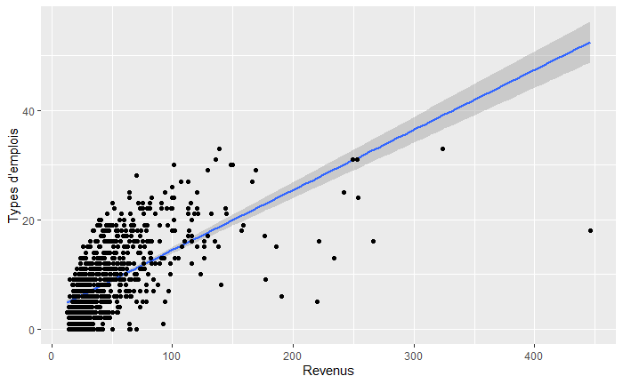

```r
ggplot(df_bank) +
  aes(x = income, y = employ) +
  geom_smooth(method = "lm") +
  geom_point() +
  xlab("Revenus") +
  ylab("Types d'emplois")
```

```r
cor(df_bank$income, df_bank$employ) ^ 2
```

```
[1] 0.3907407
```

Ici on voit qu’il y a un lien fort entre le type d’emploi et le revenu, ce qui en soit parait assez évident, pour autant la régression linéaire ici n’explique que 39% de la variance totale.

# Synthèse

| Fonctions R | Univariées / biavariées / Multivariées | Types de graphiques |
| --- | --- | --- |
| Histograme | Univarié | `geom_histogram()` |
| Courbe gaussian ou non | Univarié | `geom_density()` |
| Boite à moustache | Univarié et bivarié | `geom_boxplot()` |
| Diagramme en bâtons | Univarié | `geom_bar()` |
| Nuage de points | Bivarié | `geom_point()` |
| **Quelques plus** |  |  |
| Matrice de corrélations | Bivarié et multivarié | `corrplot()` |
| Régression linéaire | Bivarié | `geom_smooth()` |